```r
library(knitr)
opts_chunk$set(background='gray80', tidy=FALSE, cache=FALSE)
```

# PickleBox2014

## Analyze subsets

*James F Meadow* (`jfmeadow at gmail dot com`)

```r
# rm(list=ls())
# setwd('~/Dropbox/Pickle2014/R')
library(vegan)
library(labdsv)
library(ape)
library(scales)
```

Load particle count data and previous Rdata from `pb2014.Rmd` script.

```r
rm(list=ls())
load('pb2014.RData')
load('particle/particleCounts.RData')
```

```r
set.seed(1314)
```

```r
tab.big <- tab
map.big <- map
taxa.big <- taxa
```

```r
dim(tab.big)
```

```
## [1]  222 5028
```

```r
row.names(tab.big)
```

```
##   [1] "f.h.s02.1"    "f.h.s02.3"    "f.l.s06.sup1" "f.l.s06.sup2"
##   [5] "f.l.s06.sup3" "f.l.s05.4"    "f.l.s05.5"    "f.l.s05.6"
##   [9] "f.l.s05.exh1" "f.l.s05.exh2" "f.l.s05.exh3" "f.l.s08.5"
##  [13] "f.l.s08.6"    "f.l.s07.4"    "f.l.s07.5"    "f.l.s07.6"
##  [17] "f.h.s06.4"    "f.h.s06.5"    "f.h.s06.6"    "f.l.s04.exh1"
##  [21] "f.l.s04.exh2" "f.l.s04.exh3" "f.l.s06.1"    "f.l.s06.3"
##  [25] "f.l.s04.1"    "f.l.s04.2"    "f.l.s04.3"    "f.h.s03.sup1"
##  [29] "f.h.s03.sup2" "f.h.s03.sup3" "f.h.s06.1"    "f.h.s06.2"
##  [33] "f.h.s06.3"    "f.h.s08.1"    "f.h.s08.2"    "f.h.s08.3"
##  [37] "f.h.s07.sup1" "f.h.s07.sup2" "f.h.s07.sup3" "f.l.s01.1"
##  [41] "f.l.s01.2"    "f.l.s01.3"    "f.l.s07.1"    "f.l.s07.2"
##  [45] "f.l.s07.3"    "f.l.s01.sup1" "f.l.s01.sup2" "f.l.s01.sup3"
##  [49] "f.l.s05.1"    "f.l.s05.2"    "f.l.s05.3"    "f.h.s08.4"
##  [53] "f.h.s08.5"    "f.h.s08.6"    "f.l.s03.4"    "f.l.s03.5"
##  [57] "f.l.s03.6"    "f.l.s02.1"    "f.l.s02.2"    "f.l.s02.3"
```

[output cut: 41 more lines]

Subset into individuals for exploration.

```r
# sort(rowSums(tab.filtersHigh))
# sort(rowSums(tab.filtersLow))

s1high <- Reduce(intersect, list(filters, high, s1))
s2high <- Reduce(intersect, list(filters, high, s2))
s3high <- Reduce(intersect, list(filters, high, s3))
s4high <- Reduce(intersect, list(filters, high, s4))
s5high <- Reduce(intersect, list(filters, high, s5))
s6high <- Reduce(intersect, list(filters, high, s6))
s7high <- Reduce(intersect, list(filters, high, s7))
s8high <- Reduce(intersect, list(filters, high, s8))

s1low <- Reduce(intersect, list(filters, low, s1))
s2low <- Reduce(intersect, list(filters, low, s2))
s3low <- Reduce(intersect, list(filters, low, s3))
s4low <- Reduce(intersect, list(filters, low, s4))
s5low <- Reduce(intersect, list(filters, low, s5))
s6low <- Reduce(intersect, list(filters, low, s6))
s7low <- Reduce(intersect, list(filters, low, s7))
s8low <- Reduce(intersect, list(filters, low, s8))

allLow <- Reduce(intersect, list(filters, low, inside))
allHigh <- Reduce(intersect, list(filters, high, inside))
```

```r
pbDist <- 'bray'
# pbDist <- 'canberra'
```

Change subject numbers so it flows with previous experiment.

```r
map$Subject2[map$Subject == 's01'] <- 's04'
map$Subject2[map$Subject == 's02'] <- 's05'
map$Subject2[map$Subject == 's03'] <- 's06'
map$Subject2[map$Subject == 's04'] <- 's07'
map$Subject2[map$Subject == 's05'] <- 's08'
map$Subject2[map$Subject == 's06'] <- 's09'
map$Subject2[map$Subject == 's07'] <- 's10'
map$Subject2[map$Subject == 's08'] <- 's11'
map$Subject2 <- factor(map$Subject2,
                           levels=c('s11', 's09', 's08', 's05', 's07', 's04', 's10', 's06'))
```

Get sub dataset of occupied samples from low air flow.

```r
occLow <- which(map$Location == 'inside' & map$Treatment == 'low')
occTab <- tab[occLow, ]
occTab <- occTab[sort(row.names(occTab)), ]
occTab <- occTab/rowSums(occTab)
occMap <- map[row.names(occTab), ]
```

Create dataset of just targetted human-associated families. This list comes from the most influencial indicator taxa we found in the first experiment.

```r
humAss <- sort(c(grep('Corynebacteriaceae', taxa$Family),
                 grep('Staphylococcaceae', taxa$Family),
                 grep('Streptococcaceae', taxa$Family),
                 grep('Lactobacillaceae', taxa$Family),
                 grep('Propionibacteriaceae', taxa$Family),
                 grep('Peptostreptococcaceae', taxa$Family),
                 grep('Bifidobacteriaceae', taxa$Family),
                 grep('Micrococcaceae', taxa$Family),
                 grep('Carnobacteriaceae', taxa$Family),
                 grep('Dietziaceae', taxa$Family),
                 grep('Aerococcaceae', taxa$Family),
                 grep('Tissierellaceae', taxa$Family)))


occTabHA <- occTab[, humAss]
occTaxHA <- taxa[humAss, ]

tabHA <- (tab/rowSums(tab))[, humAss]

identical(colnames(occTabHA), row.names(occTaxHA))
```

```
## [1] TRUE
```

```r
identical(row.names(occTabHA), row.names(occMap))
```

```
## [1] TRUE
```

Check order of subjects and their colors.

```r
# occMap
unique(occMap$col)
```

```
## [1] "#00A08A" "#FF0000" "#F2AD00" "#F98400" "#5BBCD6" "#046C9A" "#D69C4E"
## [8] "#ABDDDE"
```

```r
levels(occMap$Subject)
```

```
## [1] "s01" "s02" "s03" "s04" "s05" "s06" "s07" "s08"
```

Reorder subjects for plotting clarity.

```r
occMap$SubOrder <- factor(occMap$Subject, levels=c('s08', 's06', 's05', 's02', 's04', 's01', 's07', 's03'))
subOrder <- c(8,6,5,2,4,1,7,3)

# Change names to make manuscript flow between 2 experiments.
occMap$SubOrder2[occMap$SubOrder == 's01'] <- 's04'
occMap$SubOrder2[occMap$SubOrder == 's02'] <- 's05'
occMap$SubOrder2[occMap$SubOrder == 's03'] <- 's06'
occMap$SubOrder2[occMap$SubOrder == 's04'] <- 's07'
occMap$SubOrder2[occMap$SubOrder == 's05'] <- 's08'
occMap$SubOrder2[occMap$SubOrder == 's06'] <- 's09'
occMap$SubOrder2[occMap$SubOrder == 's07'] <- 's10'
occMap$SubOrder2[occMap$SubOrder == 's08'] <- 's11'
occMap$SubOrder2 <- factor(occMap$SubOrder2,
                           levels=c('s11', 's09', 's08', 's05', 's07', 's04', 's10', 's06'))
```

Get a list of the subjects in order.

```r
slows <- list(s1low, s2low, s3low, s4low, s5low, s6low, s7low, s8low)
cols <- unique(occMap$col)
```

Create function to plot the tree with the targeted OTU bar plots.

```r
clMeth <- 'ward'
pbDist <- 'bray'
# set <- occLow
# rrare <- 0
# ptOffset <- .4

plotAllSubjectsTreeBars <- function(set, pbDist='bray', rrare=0, ptOffset=.4,
                                    bar0=47, barlen=20, cutLine=FALSE, x..lim=65, keep=FALSE) {
  these <- set
  dat <- tabHA[these, ]
  dat <- dat[which(rowSums(dat) >= rrare), ]
  bars <- rowSums(dat)
  Dist <- vegdist(dat, pbDist)
  dend <- hclust(Dist, method=clMeth)
  phy <- as.phylo(dend)

  Map <- map[row.names(dat), ]
  phy$tip.label <- as.character(Map$Subject2)
  phy$order <- dend$order

  par(mar=c(4,0,1,1))
  plot(phy, show.tip.label=TRUE, use.edge.length=FALSE,
    tip.color=Map$col, font=4, label.offset=1.5, cex=1.5,
    edge.width=2, edge.color='gray50', x.lim=x..lim)
  tiplabels(pch=22, bg=Map$col, col='gray40', cex=2.4, adj=1.1)

  segments(rep(bar0, length(bars)), 1:length(bars),
           rep(bar0, length(bars)) + (barlen*bars[dend$order]),
           1:length(bars),
           lwd=5, lend='butt', col=Map$col[dend$order])
  wlines <- c(bar0 + seq(.1, .6, .1)*barlen)
  segments(wlines, rep(0, length(wlines)),
           wlines, rep(length(phy$tip.label)+1, length(wlines)),
           col='white')
  axis(1, at=c(bar0, bar0+(barlen/2)), labels=c(0, .5))
  if(cutLine != FALSE) {
    cutt <- bar0 + (barlen*cutLine)
    abline(v=cutt, lty=3, col='gray60', lwd=2)
    axis(1, at=cutt, labels=cutLine)
    }
  if(keep == TRUE) {invisible(phy)}
  }
```

The subject that classify best generally have higher percentages of human associated bugs. Clearly, it works better for those who shed more during the experiment.

This was for debugging - not evaluated.

```r
# boxplot(rowSums(tabHA[occLow, ]) ~ map[occLow, 'Subject'], col=cols)
par(fg='gray30', col.axis='gray30')
boxplot(rowSums(occTabHA) ~ occMap$SubOrder2,
        col=unique(occMap$col)[c(8,6,5,2,4,1,7,3)],
        las=1, cex=0, border='gray40')
abline(h=.2, lty=3, col='gray60', lwd=2)
points(rowSums(occTabHA) ~ jitter(as.numeric(occMap$SubOrder2), .4),
       pch=16, col=rgb(0,0,0,.5))
mtext('Relative Proportion of\nTargeted Human-Associated OTUs',
      side=2, line=2.3)
mtext('Human Cloud Subjects', side=1, line=2.2)
```

Make a list of subjects who clustered well for further analysis.

```r
bestSubs <- c(Reduce(intersect, list(occLow, c(s8, s6, s5, s4, s2))))
```

Function for plotting individual occupant trees with their exhaust and supply samples.

```r
plotEachSubjectTree <- function(lst, pbDist, rrare=0, ptOffset=.4,
                                bar0=rep(16, length(lst)),
                                barlen=rep(4, length(lst)),
                                cutLine=FALSE) {
  for(i in 1:length(lst)) {
    these <- lst[[i]]
    dat <- tabHA[these, ]
    dat <- dat[which(rowSums(dat) >= rrare), ]
    bars <- rowSums(dat)
    Dist <- vegdist(dat, pbDist)
    dend <- hclust(Dist, method=clMeth)
    phy <- as.phylo(dend)
#     phy$tip.label <- gsub('^[[:alnum:]]{1}\\.[[:alnum:]]{1}\\.', '', phy$tip.label)
#     phy$tip.label <- gsub('\\.[[:digit:]]{1}$', '', phy$tip.label)
#     phy$tip.label <- gsub('s[[:digit:]]{2}\\.sup[[:digit:]]{1}$', 'sup', phy$tip.label)
#     phy$tip.label <- gsub('s[[:digit:]]{2}\\.exh[[:digit:]]{1}$', 'exh', phy$tip.label)

    bari <- bar0[i]
    if (length(barlen) == 1) {barleni <- barlen}
    if (length(barlen) !=1) {barleni <- barlen[i]}
    Map <- map[row.names(dat), ]
    phy$tip.label <- as.character(Map$Subject2)

    par(mar=c(2, 0, 1, 1))
    plot(phy, show.tip.label=FALSE, use.edge.length=FALSE,
      #tip.color=Map$col, font=4, label.offset=1.5,
      edge.width=2, edge.color='gray50', x.lim=bari+(barleni*.6))
    tiplabels(pch=22, bg=Map$col, col='gray40', cex=1.6, adj=1.1, lwd=.3)

    segments(rep(bari, length(bars)), 1:length(bars),
             rep(bari, length(bars)) + (barleni*bars[dend$order]),
             1:length(bars),
             lwd=5, lend='butt', col=Map$col[dend$order])
    wlines <- c(bari + seq(.1, .6, .1)*barleni)
    segments(wlines, rep(0, length(wlines)),
             wlines, rep(length(phy$tip.label)+1, length(wlines)),
             col='white')
    axis(1, at=c(bari, bari+(barleni/2)), labels=c(0, .5), col='gray30')
    axis(1, at=wlines[1:5], labels=FALSE, tck=-.02, col='gray30')
    if(cutLine != FALSE) {
      cutt <- bari + (barleni*cutLine)
      abline(v=cutt, lty=3, col='gray60', lwd=2)
      axis(1, at=cutt, labels=cutLine)
      }
    }
  }
```

```r
lowList <- list(s1low, s2low, s3low, s4low, s5low, s6low, s7low, s8low)
highList <- list(s1high, s2high, s3high, s4high, s5high, s6high, s7high, s8high)
```

# barplots

Set up data frames to subset distance matrices into barplots.

```r
se <- function(x) {sd(x)/sqrt(length(x))}
distLowBarDF <- data.frame(matrix(0, nrow=8, ncol=6))
distLowBarDFSE <- data.frame(matrix(0, nrow=8, ncol=6))
names(distLowBarDF) <- c('self', 'selfExh', 'selfSup', 'other', 'otherExh', 'otherSup')
names(distLowBarDFSE) <- c('self', 'selfExh', 'selfSup', 'other', 'otherExh', 'otherSup')
pbDist <- 'jaccard'


for(i in 1:8) {
  these <- lowList[[i]]
  dat <- tab[these, ]
  dat <- dat[which(rowSums(dat) >=rrare), ]
  dat <- dat[sort(row.names(dat)), ]
  Dist <- 1-vegdist(dat, pbDist)
  Map <- map[row.names(dat), ]

  self <- which(Map$Location == 'inside')
  exh <- which(Map$Location == 'exh')
  sup <- which(Map$Location == 'sup')

  DistSelf <- as.dist(as.matrix(Dist)[self, self])
  DistExh <- as.matrix(Dist)[self, exh]
  DistSup <- as.matrix(Dist)[self, sup]

  distLowBarDF$self[i] <- mean(DistSelf)
  distLowBarDF$selfExh[i] <- mean(DistExh)
  distLowBarDF$selfSup[i] <- mean(DistSup)

  distLowBarDFSE$self[i] <- se(DistSelf)
  distLowBarDFSE$selfExh[i] <- se(DistExh)
  distLowBarDFSE$selfSup[i] <- se(DistSup)

  }
```

```r
distHighBarDF <- data.frame(matrix(0, nrow=8, ncol=6))
distHighBarDFSE <- data.frame(matrix(0, nrow=8, ncol=6))
names(distHighBarDF) <- c('self', 'selfExh', 'selfSup', 'other', 'otherExh', 'otherSup')
names(distHighBarDFSE) <- c('self', 'selfExh', 'selfSup', 'other', 'otherExh', 'otherSup')

for(i in 1:8) {
  these <- highList[[i]]
  dat <- tab[these, ]
  dat <- dat[which(rowSums(dat) >=rrare), ]
  dat <- dat[sort(row.names(dat)), ]
  Dist <- 1-vegdist(dat, pbDist)
  Map <- map[row.names(dat), ]

  self <- which(Map$Location == 'inside')
  exh <- which(Map$Location == 'exh')
  sup <- which(Map$Location == 'sup')

  DistSelf <- as.dist(as.matrix(Dist)[self, self])
  DistExh <- as.matrix(Dist)[self, exh]
  DistSup <- as.matrix(Dist)[self, sup]

  distHighBarDF$self[i] <- mean(DistSelf)
  distHighBarDF$selfExh[i] <- mean(DistExh)
  distHighBarDF$selfSup[i] <- mean(DistSup)

  distHighBarDFSE$self[i] <- se(DistSelf)
  distHighBarDFSE$selfExh[i] <- se(DistExh)
  distHighBarDFSE$selfSup[i] <- se(DistSup)
  }
```

```r
distLowBarDF; distLowBarDFSE
```

```
##        self   selfExh    selfSup other otherExh otherSup
## 1 0.2648472 0.1995907 0.25741535     0        0        0
## 2 0.1962372 0.2035273 0.20188471     0        0        0
## 3 0.1573384 0.2008258 0.19271714     0        0        0
## 4 0.1414607 0.1642626 0.17389255     0        0        0
## 5 0.2097150 0.1986835 0.20953582     0        0        0
## 6 0.2791364 0.2129658 0.16728874     0        0        0
## 7 0.2358839 0.1342239 0.10466685     0        0        0
## 8 0.3011287 0.2013227 0.08559469     0        0        0
```

```
##         self    selfExh    selfSup other otherExh otherSup
## 1 0.01143592 0.01542738 0.02479075     0        0        0
## 2 0.05573245 0.03521239 0.02755907     0        0        0
## 3 0.04322342 0.02336994 0.03070367     0        0        0
## 4 0.03338369 0.03226557 0.04157889     0        0        0
## 5 0.04299291 0.03407172 0.03133159     0        0        0
## 6 0.03062736 0.03207068 0.02008725     0        0        0
## 7 0.03388314 0.01927257 0.01459449     0        0        0
## 8 0.03000927 0.01218228 0.01125259     0        0        0
```

```r
subs <- as.character(subs)
dat <- tab[which(map$Treatment == 'low'), ]
dat <- dat[which(rowSums(dat) >= rrare), ]
Map <- map[row.names(dat), ]
Dist <- as.matrix(1-vegdist(dat, pbDist))

for(i in 1:8) {
  distLowBarDF$other[i] <-
    mean(Dist[Map$Subject == subs[i] & Map$Location == 'inside',
              Map$Subject != subs[i] & Map$Location == 'inside'])
  distLowBarDF$otherExh[i] <-
    mean(Dist[Map$Subject == subs[i] & Map$Location == 'inside',
              Map$Subject != subs[i] & Map$Location == 'exh'])
  distLowBarDF$otherSup[i] <-
    mean(Dist[Map$Subject == subs[i] & Map$Location == 'inside',
              Map$Subject != subs[i] & Map$Location == 'sup'])

  distLowBarDFSE$other[i] <-
    se(Dist[Map$Subject == subs[i] & Map$Location == 'inside',
              Map$Subject != subs[i] & Map$Location == 'inside'])
  distLowBarDFSE$otherExh[i] <-
    se(Dist[Map$Subject == subs[i] & Map$Location == 'inside',
              Map$Subject != subs[i] & Map$Location == 'exh'])
  distLowBarDFSE$otherSup[i] <-
    se(Dist[Map$Subject == subs[i] & Map$Location == 'inside',
              Map$Subject != subs[i] & Map$Location == 'sup'])

  }
```

```r
distHighBarDF$selfExh[which(distHighBarDF$selfExh == 'NaN')] <- NA
distHighBarDFSE$selfExh[which(distHighBarDFSE$selfExh == 'NaN')] <- NA
subs <- as.character(subs)
dat <- tab[which(map$Treatment == 'high'), ]
dat <- dat[which(rowSums(dat) >= rrare), ]
Map <- map[row.names(dat), ]
Dist <- as.matrix(1-vegdist(dat, pbDist))

for(i in 1:8) {
  distHighBarDF$other[i] <-
    mean(Dist[Map$Subject == subs[i] & Map$Location == 'inside',
              Map$Subject != subs[i] & Map$Location == 'inside'])
  distHighBarDF$otherExh[i] <-
    mean(Dist[Map$Subject == subs[i] & Map$Location == 'inside',
              Map$Subject != subs[i] & Map$Location == 'exh'])
  distHighBarDF$otherSup[i] <-
    mean(Dist[Map$Subject == subs[i] & Map$Location == 'inside',
              Map$Subject != subs[i] & Map$Location == 'sup'])

  distHighBarDFSE$other[i] <-
    se(Dist[Map$Subject == subs[i] & Map$Location == 'inside',
              Map$Subject != subs[i] & Map$Location == 'inside'])
  distHighBarDFSE$otherExh[i] <-
    se(Dist[Map$Subject == subs[i] & Map$Location == 'inside',
              Map$Subject != subs[i] & Map$Location == 'exh'])
  distHighBarDFSE$otherSup[i] <-
    se(Dist[Map$Subject == subs[i] & Map$Location == 'inside',
              Map$Subject != subs[i] & Map$Location == 'sup'])
  }
```

Put all of that into smaller plotting dataframes.

```r
se. <- function(x) {
  len <- length(x[which(!is.na(x))])
  sd(x, na.rm=TRUE)/sqrt(len)
  }

plotLowDF <- data.frame(mean = apply(distLowBarDF, 2, mean),
                        se = apply(distLowBarDF, 2, se.))
plotHighDF <- data.frame(mean = apply(distHighBarDF, 2, mean, na.rm=TRUE),
                        se = apply(distHighBarDF, 2, se.))
plotLowDF <- plotLowDF[c(1, 4, 2, 5, 3, 6), ]
plotHighDF <- plotHighDF[c(1, 4, 2, 5, 3, 6), ]
```

```r
space=rep(c(.4, .1), 3)
cols <- c('gray', 'gray50')
ylims <- c(0, .25)
```

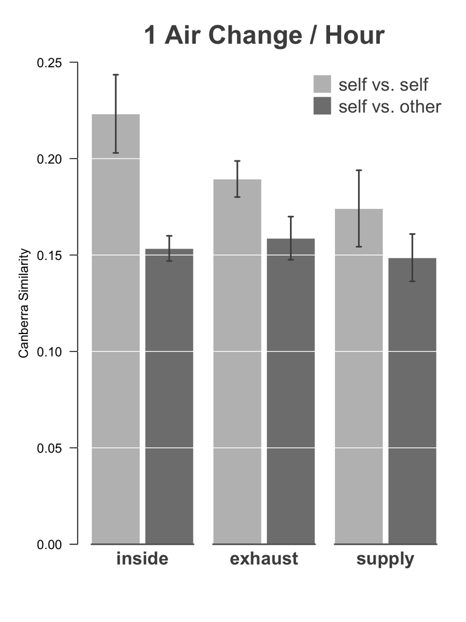

```r
df <- plotLowDF
len <- 0.03
# pdf('sixLowBar.pdf', width=6, height=8)
par(mar=c(5, 5, 4, 1), las=1)
mids <- barplot(as.matrix(df$mean), beside=TRUE,
                col=cols, border='white', space=space,
                ylim=ylims, ylab='Canberra Similarity')
abline(h=seq(0, .4, .05), col='white')
arrows(mids, df$mean+df$se, mids, df$mean-df$se,
       code=3, length=len, angle=90, col='gray30', lwd=2)
par(xpd=TRUE)
segments(mids[c(1, 3, 5)]-.5, 0, mids[c(2, 4, 6)]+.5, 0, lwd=2, col='gray40')
mtext(c('inside', 'exhaust', 'supply'), side=1, line=0.5,
      at=c(mean(mids[1:2]), mean(mids[3:4]), mean(mids[5:6])),
      font=2, cex=1.4, col='gray30')
legend('topright', legend=c('self vs. self', 'self vs. other'), pt.cex=3,
       pch=15, col=c('gray', 'gray50'), bty='n', cex=1.4, text.col='gray30')
mtext('1 Air Change / Hour', col='gray30', line=1, font=2, cex=2)
```

```r
# dev.off()
```

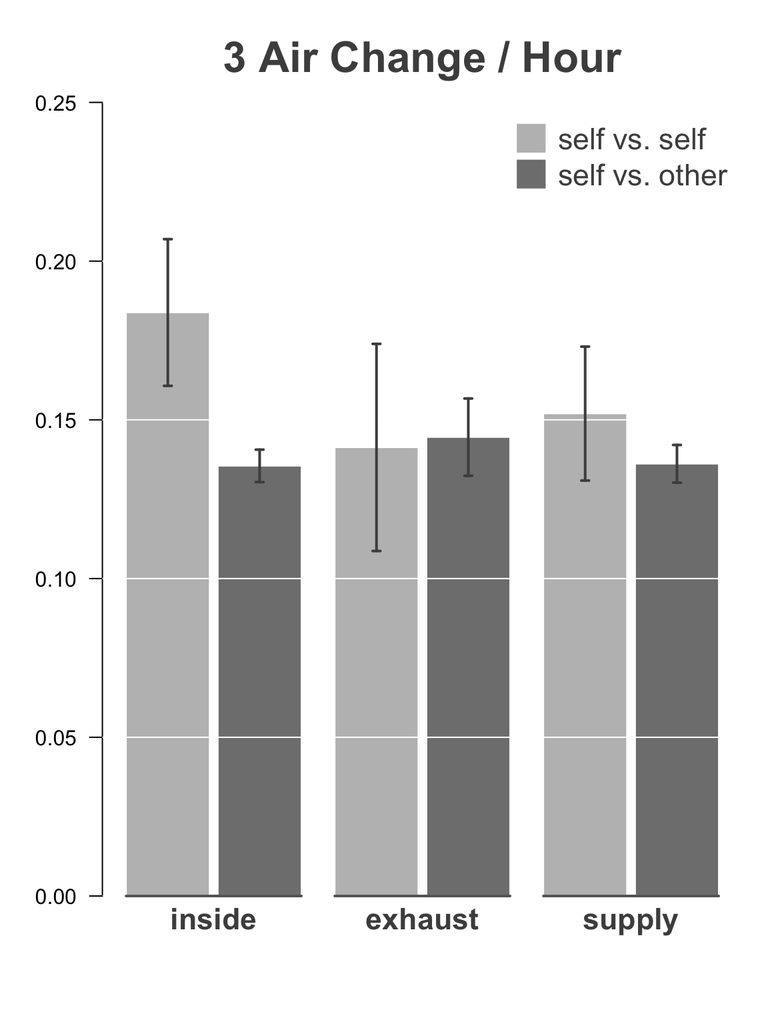

```r
df <- plotHighDF
len <- 0.03
# pdf('sixBarHigh.pdf', width=6, height=8)
par(mar=c(5, 4, 4, 1), las=1)
mids <- barplot(as.matrix(df$mean), beside=TRUE,
                col=cols, border='white', space=space,
                ylim=ylims)
abline(h=seq(0, .4, .05), col='white')
arrows(mids, df$mean+df$se, mids, df$mean-df$se,
       code=3, length=len, angle=90, col='gray30', lwd=2)
par(xpd=TRUE)
segments(mids[c(1, 3, 5)]-.5, 0, mids[c(2, 4, 6)]+.5, 0, lwd=2, col='gray40')
mtext(c('inside', 'exhaust', 'supply'), side=1, line=0.5,
      at=c(mean(mids[1:2]), mean(mids[3:4]), mean(mids[5:6])),
      font=2, cex=1.4, col='gray30')
legend('topright', legend=c('self vs. self', 'self vs. other'), pt.cex=3,
       pch=15, col=c('gray', 'gray50'), bty='n', cex=1.4, text.col='gray30')
mtext('3 Air Change / Hour', col='gray30', line=1, font=2, cex=2)
```

```r
# dev.off()
```

Make supplementary barplot.

```r
df <- plotLowDF
len <- 0.03
space <- rep(c(.8, .02), 3)
pdf('suppBarplots2.pdf', width=7, height=5)
layout(matrix(c(1,2), 1, 2), widths=c(1, .9))
par(mar=c(5, 5, 4, 1), las=1)
mids <- barplot(as.matrix(df$mean), beside=TRUE,
                col='gray', border='white', space=space,
                ylim=ylims, ylab='Jaccard Similarity', yaxt='n')
abline(h=seq(0, .4, .05), col='white')
axis(2, tck=.02, labels=FALSE)
axis(2, tick=FALSE, line=-.6)
arrows(mids, df$mean+df$se, mids, df$mean-df$se,
       code=3, length=len, angle=90, col='gray30', lwd=2)
par(xpd=TRUE)
segments(mids[c(1, 3, 5)]-.5, 0, mids[c(2, 4, 6)]+.5, 0, lwd=2, col='gray40')
mtext(c('self', 'other'), side=1, line=0,
      at=mids, font=1, cex=.8, col='gray30')
mtext(c('Inside', 'Exhaust', 'Supply'), side=1, line=1,
      at=c(mean(mids[1:2]), mean(mids[3:4]), mean(mids[5:6])),
      font=2, cex=1, col='gray30')
mtext('1 Air Change / Hour', col='gray30', line=1, font=2, cex=1)
# legend('topright', legend=c('self vs. self', 'self vs. other'), pt.cex=3,
#        pch=15, col=c('gray', 'gray50'), bty='n', cex=1.4, text.col='gray30')

df <- plotHighDF
par(mar=c(5, 3, 4, 1), las=1)
mids <- barplot(as.matrix(df$mean), beside=TRUE,
                col='gray', border='white', space=space,
                ylim=ylims, yaxt='n')
abline(h=seq(0, .4, .05), col='white')
axis(2, tck=.02, labels=FALSE)
axis(2, tick=FALSE, line=-.6)
arrows(mids, df$mean+df$se, mids, df$mean-df$se,
       code=3, length=len, angle=90, col='gray30', lwd=2)
par(xpd=TRUE)
segments(mids[c(1, 3, 5)]-.5, 0, mids[c(2, 4, 6)]+.5, 0, lwd=2, col='gray40')
mtext(c('self', 'other'), side=1, line=0,
      at=mids, font=1, cex=.8, col='gray30')
mtext(c('Inside', 'Exhaust', 'Supply'), side=1, line=1,
      at=c(mean(mids[1:2]), mean(mids[3:4]), mean(mids[5:6])),
      font=2, cex=1, col='gray30')
mtext('3 Air Changes / Hour', col='gray30', line=1, font=2, cex=1)
dev.off()
```

## Particle count data

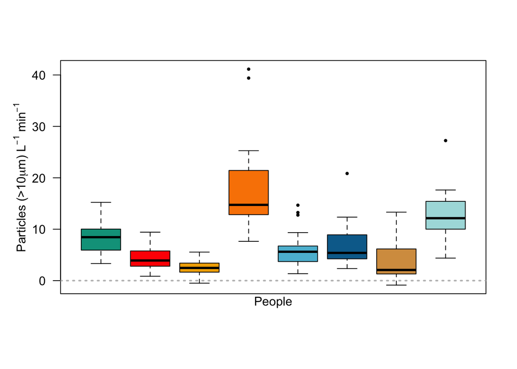

```r
boxplot(Agg.df$diff10 ~ Agg.df$group, cex=.6, col=unique(occMap$col),
        pch=16, las=1, xaxt='n', ylab='')
mtext(expression(paste('Particles (>10', mu, 'm) L' ^{-1},  ' min' ^{-1})),
    side=2, line=2)
abline(h=0, col='gray', lty=3, lwd=2)
mtext('People', side=1)
```

```r
partMean <- aggregate(Agg.df[, c('diff10', 'diff510', 'diff35', 'diff13')], by=list(Agg.df$group), FUN='mean')
partSD <- aggregate(Agg.df[, c('diff10', 'diff510', 'diff35', 'diff13')], by=list(Agg.df$group), FUN='sd')
partSE <- aggregate(Agg.df[, c('diff10', 'diff510', 'diff35', 'diff13')], by=list(Agg.df$group), FUN='se')
```

```r
haMean <- aggregate(rowSums(occTabHA), by=list(occMap$Subject), FUN='mean')
names(haMean) <- c('group', 'mean')
haMean$sd <- aggregate(rowSums(occTabHA), by=list(occMap$Subject), FUN='sd')$x
haMean$se <- aggregate(rowSums(occTabHA), by=list(occMap$Subject), FUN='se')$x
```

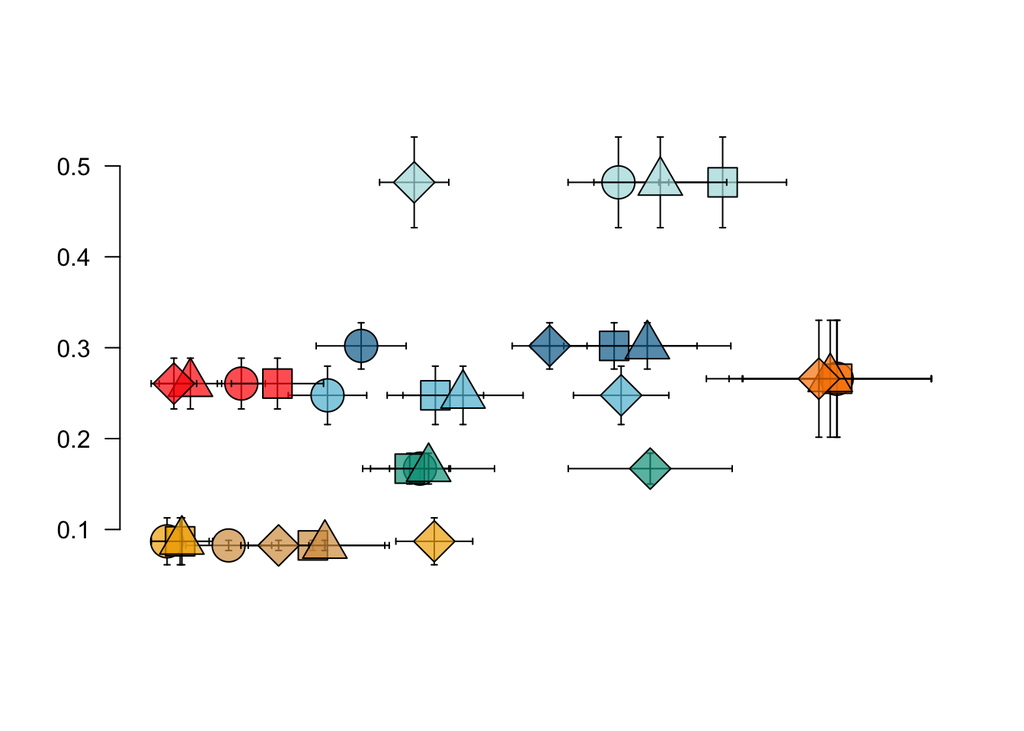

```r
# xmean <- partMean$diff10
# ymean <- haMean$mean
# xse <- partSE$diff10
# yse <- haMean$se
plotPartHA <- function(xmean=xmean, ymean=ymean, xse=xse, yse=yse, pch=21, New=FALSE) {
  x.lim <- c(min(xmean - xse),
             max(xmean + xse))
  y.lim <- c(min(ymean - yse),
             max(ymean + yse))
  if (New) {
    par(new=TRUE)
    plot(xmean, ymean, type='n',
         xlim=x.lim, ylim=y.lim, las=1,
         ann=FALSE, axes=FALSE, bty='n')
    }
  else {
    par(new=FALSE)
    plot(xmean, ymean, type='n',
         xlim=x.lim, ylim=y.lim, las=1,
         ann=FALSE, xaxt='n', bty='n')
    }
  arrows(xmean, ymean + yse,
         xmean, ymean - yse,
         code=3, angle=90, length=.02)
  arrows(xmean + xse, ymean,
         xmean - xse, ymean,
         code=3, angle=90, length=.02)
  points(xmean, ymean,
         bg=alpha(unique(occMap$col), alpha=.7),
         cex=3, pch=pch)
}


plotPartHA(partMean$diff10, haMean$mean, partSE$diff10, haMean$se)
plotPartHA(partMean$diff510, haMean$mean, partSE$diff510, haMean$se, New=TRUE, pch=22)
plotPartHA(partMean$diff35, haMean$mean, partSE$diff35, haMean$se, New=TRUE, pch=24)
plotPartHA(partMean$diff13, haMean$mean, partSE$diff13, haMean$se, New=TRUE, pch=23)
```

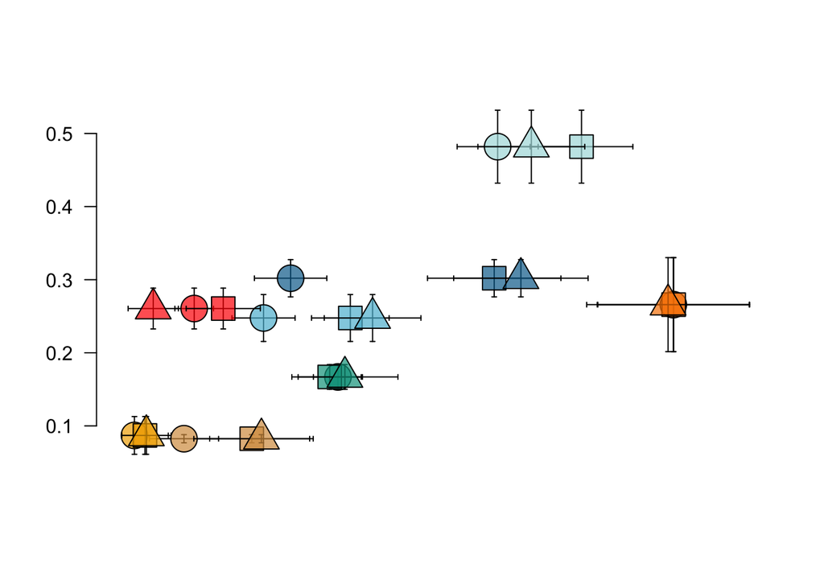

```r
plotPartHA(partMean$diff10, haMean$mean, partSE$diff10, haMean$se)
plotPartHA(partMean$diff510, haMean$mean, partSE$diff510, haMean$se, New=TRUE, pch=22)
plotPartHA(partMean$diff35, haMean$mean, partSE$diff35, haMean$se, New=TRUE, pch=24)
```

```r
# plotPartHA(partMean$diff13, haMean$mean, partSE$diff13, haMean$se, New=TRUE, pch=23)


cor.test(partMean$diff10, haMean$mean)$estimate
```

```
##       cor
## 0.5848149
```

```r
cor.test(partMean$diff510, haMean$mean)$estimate
```

```
##       cor
## 0.7158974
```

```r
cor.test(partMean$diff35, haMean$mean)$estimate
```

```
##      cor
## 0.617443
```

```r
cor.test(partMean$diff13, haMean$mean)$estimate
```

```
##        cor
## 0.09778716
```

A version of the tree plotting function that keeps the order of tips, so that data can be put on the tips in the right order.

```r
clMeth <- 'ward'
pbDist <- 'bray'

plotAllSubjectsTreeBars2 <- function(set, pbDist='bray', rrare=0, ptOffset=2,
                                    bar0=47, barlen=20, cutLine=FALSE, x..lim=65, keep=FALSE) {
  these <- set
  dat <- tabHA[these, ]
  dat <- dat[which(rowSums(dat) >= rrare), ]
  bars <- rowSums(dat)
  Dist <- vegdist(dat, pbDist)
  dend <- hclust(Dist, method=clMeth)
  phy <- as.phylo(dend)

  Map <- map[row.names(dat), ]
  phy$tip.label <- as.character(Map$Subject2)
  phy$order <- dend$order

  if (keep == FALSE) {
    par(mar=c(5,0,1,1))
    plot(phy, show.tip.label=FALSE, use.edge.length=FALSE,
      tip.color=Map$col, font=4, label.offset=1.5, cex=1.5,
      edge.width=2, edge.color='gray50', x.lim=x..lim)
    tiplabels(pch=15, col=Map$col, cex=2, adj=ptOffset)
    }

  if(keep == TRUE) {invisible(phy)}
  }
```

```r
pbDist <- 'bray'
```

## Check signif at splitting nodes.

In order to put statistics on clade separation, this was set up to get adonis test based on the current tree. After running these, statistics were put manually on the trees of the final version of the manuscript figures.

```r
Phy <- plotAllSubjectsTreeBars2(set = bestSubs, pbDist = 'bray', rrare = 0, keep = TRUE)
Phy$order
```

```
##  [1] 24  6 23  5 17 18  4 19 12  1 13  3 11 16 14 15 25 21 20 22  2  7  8
## [24]  9 10
```

```r
Phy2 <- plotAllSubjectsTreeBars2(set=occLow, pbDist='bray', rrare=.2, keep=TRUE)
# row.names(tabHA)[occLow]
row.names(tabHA)[bestSubs][Phy$order]
```

```
##  [1] "f.l.s06.5" "f.l.s06.1" "f.l.s06.4" "f.l.s08.6" "f.l.s08.1"
##  [6] "f.l.s08.2" "f.l.s08.5" "f.l.s08.3" "f.l.s05.2" "f.l.s05.4"
## [11] "f.l.s05.3" "f.l.s05.6" "f.l.s05.1" "f.l.s02.3" "f.l.s02.1"
## [16] "f.l.s02.2" "f.l.s02.4" "f.l.s04.5" "f.l.s04.4" "f.l.s04.6"
## [21] "f.l.s05.5" "f.l.s06.3" "f.l.s04.1" "f.l.s04.2" "f.l.s04.3"
```

```r
# testThese is the order on the tree being tested, from bottom to top.
checkSig <- function(these=bestSubs, order=Phy$order, testThese, pbDist='bray', clusters) {
  TAB <- tabHA[these, ][order, ][testThese, ]
  DIST <- vegdist(TAB, pbDist)
  print(adonis(DIST ~ clusters))
  }
```

Test clades in the bottom tree (bestSubs)

```r
# all in bottom tree, broken in at root.
checkSig(testThese=c(1:25), clusters=c(rep('a', 8), rep('b', 17)))
```

```
##
## Call:
## adonis(formula = DIST ~ clusters)
##
## Terms added sequentially (first to last)
##
##           Df SumsOfSqs MeanSqs F.Model      R2 Pr(>F)
## clusters   1    0.8835 0.88349  5.4047 0.19028  0.001 ***
## Residuals 23    3.7597 0.16347         0.80972
## Total     24    4.6432                 1.00000
## ---
## Signif. codes:  0 '***' 0.001 '**' 0.01 '*' 0.05 '.' 0.1 ' ' 1
```

```r
# bottom two clades
checkSig(testThese=c(1:8), clusters=c(rep('a', 3), rep('b', 5)))
```

```
##
## Call:
## adonis(formula = DIST ~ clusters)
##
## Terms added sequentially (first to last)
##
##           Df SumsOfSqs MeanSqs F.Model      R2 Pr(>F)
## clusters   1   0.35117 0.35117  7.3547 0.55072  0.019 *
## Residuals  6   0.28649 0.04775         0.44928
## Total      7   0.63766                 1.00000
## ---
## Signif. codes:  0 '***' 0.001 '**' 0.01 '*' 0.05 '.' 0.1 ' ' 1
```

```r
# top 3 clades, broken at 13/14
checkSig(testThese=c(9:25), clusters=c(rep('a', 5), rep('b', 12)))
```

```
##
## Call:
## adonis(formula = DIST ~ clusters)
##
## Terms added sequentially (first to last)
##
##           Df SumsOfSqs MeanSqs F.Model      R2 Pr(>F)
## clusters   1   0.65427 0.65427  3.9768 0.20956  0.001 ***
## Residuals 15   2.46781 0.16452         0.79044
## Total     16   3.12209                 1.00000
## ---
## Signif. codes:  0 '***' 0.001 '**' 0.01 '*' 0.05 '.' 0.1 ' ' 1
```

```r
# top 2 clades, red vs orange
checkSig(testThese=c(14:25), clusters=c(rep('a', 4), rep('b', 8)))
```

```
##
## Call:
## adonis(formula = DIST ~ clusters)
##
## Terms added sequentially (first to last)
##
##           Df SumsOfSqs MeanSqs F.Model     R2 Pr(>F)
## clusters   1   0.66172 0.66172  4.6564 0.3177  0.005 **
## Residuals 10   1.42110 0.14211         0.6823
## Total     11   2.08282                 1.0000
## ---
## Signif. codes:  0 '***' 0.001 '**' 0.01 '*' 0.05 '.' 0.1 ' ' 1
```

```r
# Check top clade mess
checkSig(testThese=c(18:25), clusters=c(rep('a', 3), rep('b', 5)))
```

```
##
## Call:
## adonis(formula = DIST ~ clusters)
##
## Terms added sequentially (first to last)
##
##           Df SumsOfSqs MeanSqs F.Model      R2 Pr(>F)
## clusters   1   0.37846 0.37846  3.2755 0.35314   0.02 *
## Residuals  6   0.69325 0.11554         0.64686
## Total      7   1.07171                 1.00000
## ---
## Signif. codes:  0 '***' 0.001 '**' 0.01 '*' 0.05 '.' 0.1 ' ' 1
```

Test clades in top tree (`rrare=.2`)

```r
check2 <- which(rowSums(tabHA)[occLow] > .2)
row.names(tabHA)[occLow][check2][Phy2$order]
```

```
##  [1] "f.l.s08.6" "f.l.s08.1" "f.l.s08.2" "f.l.s08.5" "f.l.s08.3"
##  [6] "f.l.s05.4" "f.l.s05.3" "f.l.s05.6" "f.l.s05.1" "f.l.s02.3"
## [11] "f.l.s02.1" "f.l.s02.2" "f.l.s02.4" "f.l.s06.3" "f.l.s06.5"
## [16] "f.l.s06.1" "f.l.s06.4" "f.l.s04.5" "f.l.s04.4" "f.l.s04.6"
## [21] "f.l.s01.5" "f.l.s01.6"
```

```r
these.2 <- occLow[check2]
# bottom two clades
checkSig(these=these.2, order=Phy2$order, testThese=c(1:9), clusters=c(rep('a', 5), rep('b', 4)))
```

```
##
## Call:
## adonis(formula = DIST ~ clusters)
##
## Terms added sequentially (first to last)
##
##           Df SumsOfSqs MeanSqs F.Model      R2 Pr(>F)
## clusters   1   0.53075 0.53075  9.9455 0.58691  0.009 **
## Residuals  7   0.37356 0.05337         0.41309
## Total      8   0.90431                 1.00000
## ---
## Signif. codes:  0 '***' 0.001 '**' 0.01 '*' 0.05 '.' 0.1 ' ' 1
```

```r
# s08 vs all other above
checkSig(these=these.2, order=Phy2$order, testThese=c(6:22), clusters=c(rep('a', 4), rep('b', 13)))
```

```
##
## Call:
## adonis(formula = DIST ~ clusters)
##
## Terms added sequentially (first to last)
##
##           Df SumsOfSqs MeanSqs F.Model      R2 Pr(>F)
## clusters   1   0.60192 0.60192  3.8817 0.20558  0.001 ***
## Residuals 15   2.32598 0.15507         0.79442
## Total     16   2.92790                 1.00000
## ---
## Signif. codes:  0 '***' 0.001 '**' 0.01 '*' 0.05 '.' 0.1 ' ' 1
```

```r
# s05 vs all above
checkSig(these=occLow[check2], order=Phy2$order, testThese=c(10:22), clusters=c(rep('a', 4), rep('b', 9)))
```

```
##
## Call:
## adonis(formula = DIST ~ clusters)
##
## Terms added sequentially (first to last)
##
##           Df SumsOfSqs MeanSqs F.Model      R2 Pr(>F)
## clusters   1   0.53393 0.53393  3.7657 0.25503  0.004 **
## Residuals 11   1.55967 0.14179         0.74497
## Total     12   2.09361                 1.00000
## ---
## Signif. codes:  0 '***' 0.001 '**' 0.01 '*' 0.05 '.' 0.1 ' ' 1
```

```r
# s09 vs all above
checkSig(these=occLow[check2], order=Phy2$order, testThese=c(14:22), clusters=c(rep('a', 4), rep('b', 5)))
```

```
##
## Call:
## adonis(formula = DIST ~ clusters)
##
## Terms added sequentially (first to last)
##
##           Df SumsOfSqs MeanSqs F.Model      R2 Pr(>F)
## clusters   1   0.38707 0.38707  3.2914 0.31982  0.007 **
## Residuals  7   0.82321 0.11760         0.68018
## Total      8   1.21029                 1.00000
## ---
## Signif. codes:  0 '***' 0.001 '**' 0.01 '*' 0.05 '.' 0.1 ' ' 1
```

```r
# s07 vs s04
checkSig(these=occLow[check2], order=Phy2$order, testThese=c(18:22), clusters=c(rep('a', 3), rep('b', 2)))
```

```
##
## Call:
## adonis(formula = DIST ~ clusters)
##
## Terms added sequentially (first to last)
##
##           Df SumsOfSqs MeanSqs F.Model     R2 Pr(>F)
## clusters   1   0.34423 0.34423  5.0086 0.6254  0.103
## Residuals  3   0.20618 0.06873         0.3746
## Total      4   0.55041                 1.0000
```

## Big figure

This is the figure that ends up in the manuscript.

```r
pdf('secondExpPanels.pdf', width=11, height=7, useDingbats=FALSE)
layout(matrix(c(1,1,2:5), 2, 3), widths=c(1, .7, .7), heights=c(.9, 1))

plotAllSubjectsTreeBars(occLow, pbDist=pbDist, rrare=0, cutLine=.2,
                        x..lim=72, bar0=48, barlen=26)
par(xpd=TRUE)
text(52, -3, 'Targeted OTUs', col='gray20', cex=1.2)
par(xpd=FALSE)

par(fg='gray30', col.axis='gray30', bty='l')
boxplot(rowSums(occTabHA) ~ occMap$SubOrder2,
        col=unique(occMap$col)[c(8,6,5,2,4,1,7,3)],
        las=1, cex=0, border='gray40')
abline(h=.2, lty=3, col='gray60', lwd=2)
points(rowSums(occTabHA) ~ jitter(as.numeric(occMap$SubOrder2), .4),
       pch=16, col=rgb(0,0,0,.5))
mtext('Relative Abundance of\nTargeted Human-Associated OTUs',
      side=2, line=2.3)
mtext('Human Cloud Subjects', side=1, line=2.2)

par(mar=c(8, 0, 1, 5))
plotPartHA(partMean$diff10, haMean$mean, partSE$diff10, haMean$se)
axis(side=1, line=0, tck=0.01, labels=FALSE)
axis(side=1, line=-1, tck=0.0, lwd=0, lwd.ticks=0)
plotPartHA(partMean$diff510, haMean$mean, partSE$diff510, haMean$se, New=TRUE, pch=22)
axis(side=1, line=2, tck=0.01, labels=FALSE)
axis(side=1, line=1, tck=0.0, lwd=0, lwd.ticks=0)
plotPartHA(partMean$diff35, haMean$mean, partSE$diff35, haMean$se, New=TRUE, pch=24)
axis(side=1, line=4, tck=0.01, labels=FALSE)
axis(side=1, line=3, tck=0.0, lwd=0, lwd.ticks=0)
# plotPartHA(partMean$diff13, haMean$mean, partSE$diff13, haMean$se, New=TRUE, pch=23)
# axis(side=1, line=6, tck=0.01, labels=FALSE)
# axis(side=1, line=5, tck=0.0, lwd=0, lwd.ticks=0)

abline(h=.2, lty=3, col='gray60', lwd=2)
par(xpd=TRUE)
points(rep(146, 3), c(.05, 0, -.05),
       pch=c(21, 22, 24), cex=2,
       bg='gray40', col='gray40')
text(rep(147, 3), c(.05, 0, -.05)-.005,
     c(expression(paste('>10', mu, 'm')),
       expression(paste('5-10', mu, 'm')),
       expression(paste('2.5-5', mu, 'm'))), pos=4)
mtext(expression(paste('Airborne Particle Load L' ^{-1},  ' 10-min' ^{-1})),
      side=1, line=6)
mtext('Relative Abundance of\nTargeted Human-Associated OTUs',
      side=2, line=2.3)


par(xpd=FALSE)
plotAllSubjectsTreeBars(occLow, pbDist=pbDist, rrare=.2,
                        bar0=28, barlen=25, x..lim=45)
par(xpd=TRUE)
text(34, -3, 'Targeted OTUs', col='gray20', cex=1.2)
par(xpd=FALSE)


plotAllSubjectsTreeBars(bestSubs, pbDist=pbDist, rrare=0,
                        bar0=32, barlen=27, x..lim=50)
par(xpd=TRUE)
text(39, -3, 'Targeted OTUs', col='gray20', cex=1.2)
par(xpd=FALSE)


par(mfrow=c(1,1), mar=c(0,0,0,0), new=TRUE)
plot(1,1, xlim=c(0, 1), ylim=c(0, 1), xaxs='i', yaxs='i',
     axes=FALSE, ann=FALSE, type='n')




text(c(.05, .67, .67, .75, .75),
     c(.95, .95, .47, .95, .47),
     c('(a)', '(b)', '(c)', '(d)', '(e)'),
     col='gray20', font=2, cex=1.5)

dev.off()
```

Manuscript figure that shows three example trees - each with occupied, exhaust, and supply samples.

```r
pdf('threeExampleTrees.pdf', width=2, height=4.5)
# par(mfrow=c(3, 1))
layout(matrix(c(1, 2, 3, 4), 4, 1), heights=c(1,1,1,.2))
plotEachSubjectTree(lst=lowList[c(8,2,7)], pbDist=pbDist,
                    bar0=c(11.2, 10.2, 12.3), barlen=c(8.4, 7.6, 9.3))




par(mfrow=c(1,1), mar=c(0,0,0,0), new=TRUE)
plot(1,1, xlim=c(0, 1), ylim=c(0, 1), xaxs='i', yaxs='i',
     axes=FALSE, ann=FALSE, type='n')
text(.75, .04, 'Relative Abundance\nof Targeted OTUs',
     col='gray20', cex=.6)
text(c(rep(0, 3)),
     c(.96, .66, .34),
     c('(a)', '(b)', '(c)'),
     col='gray20', font=2, cex=1, pos=4)

legdf <- data.frame(x=c(.04, .04, .04, .1, .16),
                    y=c(.03, .06, .09, .09, .09),
                    col=c('#ECCBAE', # exhaust
                          'gray', # supply
                          '#ABDDDE', # s08
                          '#FF0000', # s02
                          '#D69C4E'  # s07
                          ))

points(legdf$x, legdf$y, pch=22, col='gray30',
       bg=as.character(legdf$col), cex=1.3, lwd=.3)
text(c(.16, .04, .04), c(.09, .06, .03),
     c('  Subjects', '.......... Supply Air', '.......... Exhaust Air'),
     pos=4, col='gray30', cex=.6)


dev.off()
```

```r
# (lst, pbDist, rrare=0, ptOffset=.4,
# bar0=rep(16, length(lst)), barlen=4, cutLine=FALSE)
```

```r
space=rep(c(.4, .1), 3)
cols <- c('gray', 'gray50')
```

```r
lowLim <- c(16, 14, 14, 15, 16, 14, 16, 15)
highLim <- c(15, 14, 16, 15, 14, 16, 16, 16)
```

```r
pdf('bigPlotManyTrees.pdf', height=14, width=6)
layout(matrix(c(1, 3:10, 1, 11:18, 2, 19:26, 2, 27:34), 9, 4),
       heights=c(3, rep(1, 8)))

df <- plotLowDF
len <- 0.03
# pdf('sixBarBoth.pdf', width=10, height=8)
# layout(matrix(c(1,2), 1, 2), widths=c(1, .8))
par(mar=c(5, 5, 3, 1), las=1)
mids <- barplot(as.matrix(df$mean), beside=TRUE,
                col=cols, border='white', space=space,
                ylim=c(0, .4), ylab='Canberra Similarity')
abline(h=seq(0, .4, .05), col='white')
arrows(mids, df$mean+df$se, mids, df$mean-df$se,
       code=3, length=len, angle=90, col='gray30', lwd=2)
par(xpd=TRUE)
segments(mids[c(1, 3, 5)]-.5, 0, mids[c(2, 4, 6)]+.5, 0, lwd=2, col='gray40')
mtext(c('inside', 'exhaust', 'supply'), side=1, line=0.5,
      at=c(mean(mids[1:2]), mean(mids[3:4]), mean(mids[5:6])),
      font=2, cex=1, col='gray30')
mtext('1 Air Change / Hour', col='gray30', line=.5, font=2, cex=1.2)

df <- plotHighDF
par(mar=c(5, 2, 3, 4), las=1)
mids <- barplot(as.matrix(df$mean), beside=TRUE,
                col=cols, border='white', space=space,
                ylim=c(0, .4), yaxt='n')
abline(h=seq(0, .4, .05), col='white')
arrows(mids, df$mean+df$se, mids, df$mean-df$se,
       code=3, length=len, angle=90, col='gray30', lwd=2)
par(xpd=TRUE)
segments(mids[c(1, 3, 5)]-.5, 0, mids[c(2, 4, 6)]+.5, 0, lwd=2, col='gray40')
mtext(c('inside', 'exhaust', 'supply'), side=1, line=0.5,
      at=c(mean(mids[1:2]), mean(mids[3:4]), mean(mids[5:6])),
      font=2, cex=1, col='gray30')
legend('topright', legend=c('self vs. self', 'self vs. other'), pt.cex=3,
       pch=15, col=c('gray', 'gray50'), bty='n', cex=1.4, text.col='gray30')
mtext('3 ACH', col='gray30', line=.5, font=2, cex=1.2)


plotEachSubjectTree(lowList[subOrder], pbDist, rrare=0, ptOffset=33,
                    bar0=lowLim[subOrder]-3, barlen=15)
plotEachSubjectTree(highList[subOrder], pbDist, rrare=0, ptOffset=33,
                    bar0=highLim[subOrder]-3, barlen=15)


par(mar=c(0.2,1,1,1))
space=rep(c(.4, .1), 3)
cols <- c('gray', 'gray50')

df <- distLowBarDF[subOrder, c(1,4,2,5,3,6)]
dfSE <- distLowBarDFSE[subOrder, c(1,4,2,5,3,6)]
barcols <- unique(occMap$col)[subOrder]

for(i in 1:8) {
  mids <- barplot(as.matrix(df[i, ]), beside=TRUE,
                  col=c(barcols[i], cols[2]), border='white',
                  space=space, ylim=c(0, .5), ylab='',
                  axes=FALSE, names.arg=rep('', 6))
  abline(h=seq(0, .5, .1), col='white')
  arrHigh <- unlist(df[i,]+dfSE[i,])
  arrLow <- unlist(df[i,]-dfSE[i,])
  arrows(mids, arrHigh, mids, arrLow,
         code=3, length=len, angle=90, col='gray30', lwd=2)
  par(xpd=TRUE)
  segments(mids[c(1, 3, 5)]-.5, 0, mids[c(2, 4, 6)]+.5, 0, lwd=2, col='gray40')
}

df <- distHighBarDF[subOrder, c(1,4,2,5,3,6)]
dfSE <- distHighBarDFSE[subOrder, c(1,4,2,5,3,6)]
barcols <- unique(occMap$col)[subOrder]

for(i in 1:8) {
  mids <- barplot(as.matrix(df[i, ]), beside=TRUE,
                  col=c(barcols[i], cols[2]), border='white',
                  space=space, ylim=c(0, .5), ylab='',
                  axes=FALSE, names.arg=rep('', 6))
  abline(h=seq(0, .5, .1), col='white')
  arrHigh <- unlist(df[i,]+dfSE[i,])
  arrLow <- unlist(df[i,]-dfSE[i,])
  arrows(mids, arrHigh, mids, arrLow,
         code=3, length=len, angle=90, col='gray30', lwd=2)
  par(xpd=TRUE)
  segments(mids[c(1, 3, 5)]-.5, 0, mids[c(2, 4, 6)]+.5, 0, lwd=2, col='gray40')
}
dev.off()
```

This creates the figure with a tree, and indicator taxa for each clade. Several steps to set it up.

```r
# these <- c(1, 2, 4, 5, 7, 8, 10, 15, 19, 24, 28, 31, 46, 48)
these2 <- c(1, 2, 5, 10, 7, 8, 15, 19, 24, 28, 31, 48)
these3 <- c(7, 5, 11, 6, 9, 10, 8, 12)
## get tip order from the tree plotting function
Phy <- plotAllSubjectsTreeBars2(bestSubs, pbDist=pbDist, rrare=0, keep=TRUE)

names(Phy)
```

```
## [1] "edge"        "edge.length" "tip.label"   "Nnode"       "order"
```

```r
tipOrderNames <- Phy$tip.label[Phy$order]
tipOrderRN <- row.names(tabHA)[bestSubs][Phy$order]

treeBars <- tabHA[tipOrderRN, these2]
treeCols <- map[tipOrderRN, 'col']
treeTaxa <- taxa[colnames(treeBars), ]
```

```r
checkRelAbu <- colnames(treeBars)[these3]
mapTreeBars <- map[row.names(treeBars), ]
subsTreeBars <- unique(mapTreeBars$Subject2)
for(i in 1:length(subsTreeBars)) {
  these <- which(mapTreeBars$Subject2 == subsTreeBars[i])
  mapThese <- mapTreeBars[these, ]
  newTab <- tabHA[row.names(mapThese), ]
  newSums <- sort(colSums(newTab), decreasing=TRUE)
  print(subsTreeBars[i])
  print(names(newSums)[1:10])
  }
```

```
## [1] s09
## Levels: s11 s09 s08 s05 s07 s04 s10 s06
##  [1] "OTU_11"   "OTU_3668" "OTU_3972" "OTU_5"    "OTU_1668" "OTU_17"
##  [7] "OTU_20"   "OTU_4748" "OTU_39"   "OTU_91"
## [1] s11
## Levels: s11 s09 s08 s05 s07 s04 s10 s06
##  [1] "OTU_22"   "OTU_3972" "OTU_17"   "OTU_4748" "OTU_11"   "OTU_4090"
##  [7] "OTU_3473" "OTU_3524" "OTU_42"   "OTU_3668"
## [1] s08
## Levels: s11 s09 s08 s05 s07 s04 s10 s06
##  [1] "OTU_539"  "OTU_3972" "OTU_5"    "OTU_17"   "OTU_4748" "OTU_1562"
##  [7] "OTU_22"   "OTU_4090" "OTU_2079" "OTU_29"
## [1] s05
## Levels: s11 s09 s08 s05 s07 s04 s10 s06
##  [1] "OTU_16"   "OTU_20"   "OTU_3972" "OTU_38"   "OTU_5"    "OTU_17"
##  [7] "OTU_4748" "OTU_11"   "OTU_30"   "OTU_29"
## [1] s07
## Levels: s11 s09 s08 s05 s07 s04 s10 s06
##  [1] "OTU_17"   "OTU_5"    "OTU_11"   "OTU_24"   "OTU_1562" "OTU_3972"
##  [7] "OTU_3877" "OTU_29"   "OTU_37"   "OTU_4959"
```

```r
# Some are selected as indicators for a single person.
# This is the same order as the following figure.

checkInd <- colnames(treeBars)[these3]
indBars <- indval(treeBars[, checkInd], clustering=treeCols)
```

```
## WARNING: renumbering clusters to consecutive integers
## [1] "error code =  0"
```

```r
indBars  # all are significant indicators for their respective occupant
```

```
## $relfrq
##             1         2   3         4    5
## OTU_24   0.75 0.6666667 0.8 1.0000000 0.00
## OTU_16   0.00 0.3333333 0.2 0.6666667 1.00
## OTU_539  0.00 1.0000000 1.0 0.1666667 0.00
## OTU_22   0.75 0.8333333 1.0 0.3333333 1.00
## OTU_3524 0.75 0.6666667 1.0 0.5000000 0.75
## OTU_1668 1.00 0.3333333 0.8 0.3333333 0.25
## OTU_3668 1.00 0.6666667 1.0 0.5000000 1.00
## OTU_91   1.00 0.0000000 0.2 0.5000000 0.25
##
## $relabu
##                   1          2            3            4           5
## OTU_24   0.09674287 0.07398881 0.0087010013 0.8205673135 0.000000000
## OTU_16   0.00000000 0.00565217 0.0003143016 0.0866824437 0.907351085
## OTU_539  0.00000000 0.97036546 0.0288356724 0.0007988693 0.000000000
## OTU_22   0.06661375 0.15078923 0.7583691867 0.0153707386 0.008857100
## OTU_3524 0.09840075 0.01730785 0.8439695991 0.0094450718 0.030876722
## OTU_1668 0.66809630 0.01093549 0.2951794761 0.0036907803 0.022097951
## OTU_3668 0.54842068 0.06233934 0.2866488724 0.0152673201 0.087323790
## OTU_91   0.96512067 0.00000000 0.0078576872 0.0239983101 0.003023335
##
## $indval
##                   1           2            3            4            5
## OTU_24   0.07255715 0.049325875 6.960801e-03 0.8205673135 0.0000000000
## OTU_16   0.00000000 0.001884057 6.286033e-05 0.0577882958 0.9073510846
## OTU_539  0.00000000 0.970365458 2.883567e-02 0.0001331449 0.0000000000
## OTU_22   0.04996031 0.125657688 7.583692e-01 0.0051235795 0.0088571004
## OTU_3524 0.07380057 0.011538569 8.439696e-01 0.0047225359 0.0231575415
## OTU_1668 0.66809630 0.003645164 2.361436e-01 0.0012302601 0.0055244879
## OTU_3668 0.54842068 0.041559557 2.866489e-01 0.0076336601 0.0873237900
## OTU_91   0.96512067 0.000000000 1.571537e-03 0.0119991550 0.0007558338
##
## $maxcls
##   OTU_24   OTU_16  OTU_539   OTU_22 OTU_3524 OTU_1668 OTU_3668   OTU_91
##        4        5        2        3        3        1        1        1
##
## $indcls
##    OTU_24    OTU_16   OTU_539    OTU_22  OTU_3524  OTU_1668  OTU_3668
## 0.8205673 0.9073511 0.9703655 0.7583692 0.8439696 0.6680963 0.5484207
##    OTU_91
## 0.9651207
##
## $pval
##   OTU_24   OTU_16  OTU_539   OTU_22 OTU_3524 OTU_1668 OTU_3668   OTU_91
##    0.001    0.001    0.001    0.001    0.001    0.001    0.001    0.001
##
## $error
## [1] 0
##
## attr(,"class")
## [1] "indval"
```

Create function to add barplot to the base tree.

```r
addBars <- function(thisone=1, bar0=30, bar1=39, Lines=FALSE, labcol='gray30',
                    text1='', text2='') {
  bars <- treeBars[, thisone]/max(treeBars[, thisone])
  barlen <- bar1-bar0
  lab <- which(bars == 1)
  labMax <- treeBars[lab, thisone]
  labTotal <- format(labMax, digits=2)

  if(Lines) {
    checkLines <- seq(0, 150, 5)
    abline(v=checkLines)
    mtext(checkLines, at=checkLines, cex=.4, line=0)
    }

  segments(rep(bar0, length(bars)), 1:length(bars),
           rep(bar0, length(bars)) + (barlen*bars), 1:length(bars),
           lwd=13, lend='butt', col=treeCols)
  abline(v=bar0, lwd=1, col='gray70')
  text(bar0-1, lab-.05, labTotal, pos=4, font=2, col=labcol, cex=.7)
  par(xpd=TRUE)
#   text(bar0+5, -.5, treeTaxa[thisone, 'Genus'],
#        srt=30, pos=2, cex=.7, font=4)
  text(bar0+5, -.5, text1, srt=35, pos=2, cex=.6, font=4)
  text(bar0+6, -1.1, text2, srt=35, pos=2, cex=.5, font=1)
  par(xpd=FALSE)
  }
```

This makes the tree, and the addBars function puts the barplots on one by one.

```r
pdf('clusterTaxa.pdf', width=5, height=5, useDingbats=FALSE)
plotAllSubjectsTreeBars2(bestSubs, pbDist=pbDist, rrare=0, ptOffset=3,
                        bar0=32, barlen=27, x..lim=110, keep=FALSE)

addBars(thisone=7, bar0=30, bar1=39,
        text1='Lactobacillus crispatus',
        text2='NR_119274.1 (100% similar)')
addBars(thisone=5, bar0=40, bar1=49,
        text1='Gardnerella vaginalis',
        text2='NR_074227.1 (100% similar)')
addBars(thisone=11, bar0=50, bar1=59,
        text1='Corynebacterium massiliense',
        text2='NR_044182.1 (100% similar)')
addBars(thisone=6, bar0=60, bar1=69,
        text1='Corynebacterium imitans',
        text2='NR_026369.1 (100% similar)')
addBars(thisone=9, bar0=70, bar1=79,
        text1='Corynebacterium epidermidicanis',
        text2='NR_108533.1 (98% similar)')
addBars(thisone=10, bar0=80, bar1=89, labcol='gray90',
        text1='Anaerococcus octavius',
        text2='NR_026360.1 (97% similar)')
addBars(thisone=8, bar0=90, bar1=99, labcol='gray90',
        text1='Corynebacterium sundsvallense',
        text2='NR_026375.1 (98% similar)')
addBars(thisone=12, bar0=100, bar1=109, labcol='gray90',
        text1='Propionibacterium acnes',
        text2='NR_074675.1 (96% similar)')

# addBars(thisone=9, bar0=110, bar1=119)
# addBars(thisone=10, bar0=120, bar1=129)
# addBars(thisone=8, bar0=130, bar1=139)
# addBars(thisone=12, bar0=140, bar1=149)


# addBars(thisone=1, bar0=30, bar1=39, Lines=FALSE)
# addBars(thisone=2, bar0=40, bar1=49)
# addBars(thisone=3, bar0=50, bar1=59)
# addBars(thisone=4, bar0=60, bar1=69)

dev.off()
```